# Introduction to mrgsolve part 1

Kyle T. Baron

Metrum Research Group, LLC

# A basic simulation with mrgsolve

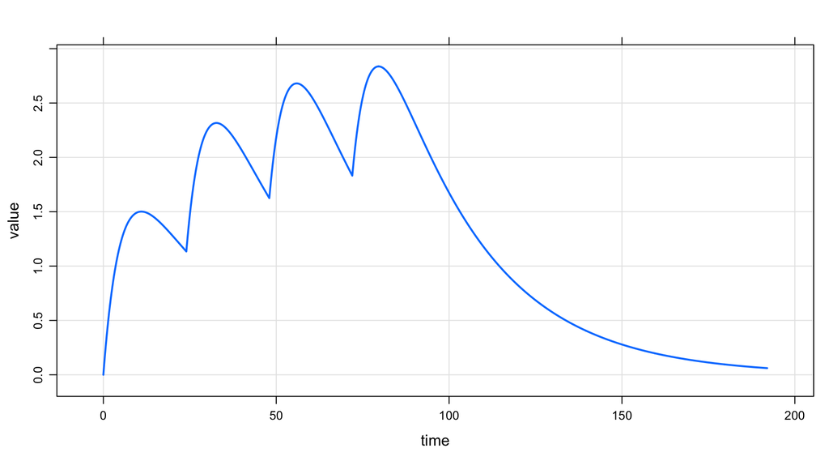

```r
mod %>% ev(amt = 100, ii = 24, addl = 3) %>% mrgsim() %>% plot()
```

# A basic simulation with mrgsolve

```r
mod %>% ev(amt = 100, ii = 24, addl = 3) %>% mrgsim() %>% plot()
```

- mod: the model object
  - Ok … where did `that` come from?
- ev(amt = 100, …) : the intervention
  - An `event` in this example
- mrgsim(): actually do the simulation
- plot(): do something with the simulation
  - `plot`, `mutate`, `as_data_frame` etc …
- model `%>%` intervention `%>%` Go! `%>%` take-a-look

# Sneak preview

- `model %>% intervention %>%` options `%>% Go! %>% ...`
- `model %>% intervention %>%` population `%>% Go! %>% ...`
- `model %>%` data-set `%>% Go! %>% ...`
- where data-set = `intervention + population`
- For now, let’s get this part down
- model `%>%` intervention `%>%` Go! `%>%` take-a-look

# What’s this thing? `%>%`

It’s called a pipe. It allows us to pass the output from one function into another function … creating a pipeline

```r
mean(sqrt(seq(4)))
```

```
. [1] 1.536566
```

```r
4  %>% seq() %>% sqrt() %>% mean()
```

```
. [1] 1.536566
```

Better.

```r
4  %>% seq(.) %>% sqrt(.) %>% mean(., na.rm = TRUE)
```

```
. [1] 1.536566
```

# The model object

model `%>% ...`

- I (almost) always call the model object mod in the documention / examples
- All the information about the model we need to know to run the simulation
- Distinct from the intervention, the population, the summary
- But the model does know about output time, random effects

# Take a look: overview

```r
mod
```

```
-------- mrgsolve model object (unix) --------
  Project: /Users/kyleb/Rli...gsolve/models
  source:        popex.cpp
  shared object: popex-so-11757148f1e82

  Time:          start: 0 end: 192 delta: 0.2
  >              add: <none>
  >              tscale: 1

  Compartments:  GUT CENT [2]
  Parameters:    TVKA TVCL TVV WT [4]
  Omega:         3x3
  Sigma:         1x1

  Solver:        atol: 1e-08 rtol: 1e-08
  >              maxsteps: 2000 hmin: 0 hmax: 0
```

# Take a look: parameters (really important)

```r
param(mod)
```

```
 Model parameters (N=4):
 name value . name value
 TVCL 1     | TVV  24
 TVKA 0.5   | WT   70
```

- Parameters get a name
- Names and number of parameters gets fixed at compile time
- All parameters have a value
- Value can be modified after compile time

# Take a look: compartments

```r
init(mod)
```

```
 Model initial conditions (N=2):
 name       value . name      value
 CENT (2)   0     | GUT (1)   0
```

- Every compartment gets a name
- Every compartment gets an initial condition

# Where did mod come from?

```r
mod <- mread("simple", "model")
```

```
. Compiling simple ... done.
```

```r
mod <- mread("<model-name>", "<project-directory>")
```

- By default mrgsolve looks for the code in the file
  - model-name.cpp in
  - project-directory
- mread demo

# Read in a model object with caching

First time to read

```r
mod <- mread_cache("simple", "model")
```

```
. Compiling simple ... done.
```

Next time to read

```r
mod <- mread_cache("simple", "model")
```

```
. Loading model from cache.
```

# Oops

```r
mod <- try(mread("simple"))

mod
```

```
. [1] "Error : the model file simple.cpp does not exist.\n"
. attr(,"class")
. [1] "try-error"
. attr(,"condition")
. <simpleError: the model file simple.cpp does not exist.>
```

# Internal model library

Quiz:

```r
mod <- mread("<first-argument>", "<second-argument>")
```

# Internal model library

Quiz:

```r
mod <- mread("<first-argument>", "<second-argument>")
```

```r
mod <- mread("<first-argument>", modlib())
```

```r
modlib()
```

```
. [1] "/Users/kyleb/Rlibs/mrgsolve/models"
```

# Internal model library

```r
mod <- mread("effect", modlib())
```

```
. Compiling effect ... done.
```

```r
mod
```

```
.
.
. -------- mrgsolve model object (unix) --------
.   Project: /Users/kyleb/Rli...gsolve/models
.   source:        effect.cpp
.   shared object: effect-so-1175758ab5ad8
.
.   Time:          start: 0 end: 36 delta: 0.1
.   >              add: <none>
.   >              tscale: 1
.
.   Compartments:  GUT CENT PERIPH CE [4]
.   Parameters:    VC KA K10 K12 K21 E0
.   >              EMAX EC50 KEO [9]
.   Omega:         0x0
.   Sigma:         0x0
.
.   Solver:        atol: 1e-08 rtol: 1e-08
.   >              maxsteps: 2000 hmin: 0 hmax: 0
```

# Inline model specification

We haven’t covered the specifics of coding a model yet

```r
code <- '
$PARAM CL = 1, V = 20
$PKMODEL cmt = "CENT"
'
```

```r
mod <- mcode("dont_do_this", code)
```

```r
mod <- mcode_cache("seriously_dont", code)
```

- Question: Why is this a bad idea?

# Your turn

- File name: chapter_02_workbook.Rmd
- Section name: Warm Up

# Event objects

- `model %>%` intervention `%>% Go! %>% take-a-look`
- Event object = quick / easy way to implement dose or other intervention

```r
e <- ev(amt = 100)

e
```

```
. Events:
.   time cmt amt evid
. 1    0   1 100    1
```

- Defaults: `time`, `evid`, `cmt`

# Three ways to invoke

Inline

```r
mod %>% ev(amt = 100) %>% mrgsim()
```

Object via pipline

```r
e <- ev(amt = 100)

mod %>% ev(e) %>% mrgsim()
```

As argument

```r
mod %>% mrgsim(events = e)
```

# What to include in `ev(...)`

- time event time
- cmt Event compartment
- amt Dose amount
- ii Inter-dose interval
- addl Additional doses to administer
- rate Infusion rate
- ss Set to 1 to advance to steady state
- evid Event id
- ID Subject ID (use multiple ids - ID=1:10)

# Interventions and corresponding `evid`

- Bolus dosing (`evid` 1, with `rate`==0)
- Zero order infusion (`evid` 1, with `rate` > 0)
- Other type event (`evid` 2)
  - This also forces solver reset
- Compartment reset (`evid` 3)
- Reset and dose (`evid` 4)
- Replace the amount in a specific compartment (`evid` 8)

# Create complex events - 1

What’s going to happen?

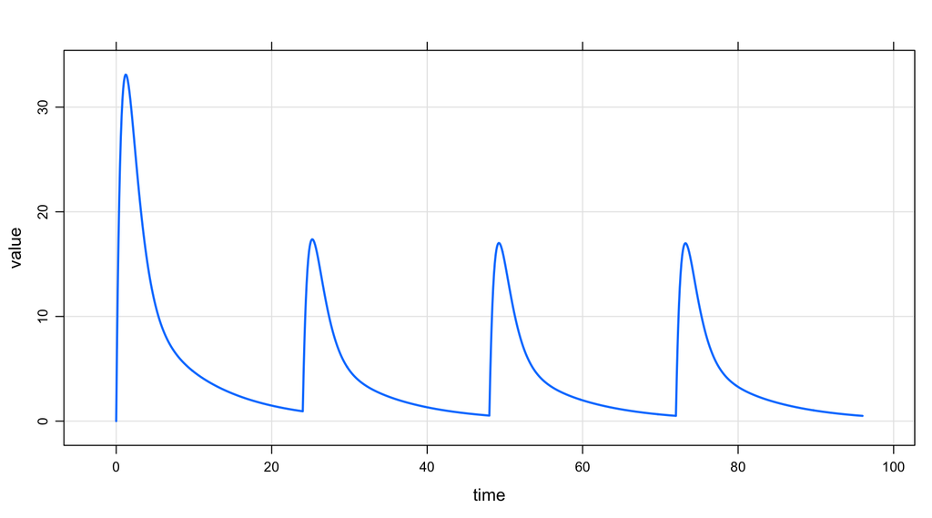

```r
e1 <- ev(amt = 200)

e2 <- ev(amt = 100, time = 24, ii = 24, addl = 4)

c(e1, e2)
```

# Create complex events - 1

Combine two events

```r
e1 <- ev(amt = 200)

e2 <- ev(amt = 100, time = 24, ii = 24, addl = 4)

c(e1, e2)
```

```
. Events:
.   time cmt amt evid ii addl
. 1    0   1 200    1  0    0
. 2   24   1 100    1 24    4
```

# Create complex events - 2

What’s going to happen?

```r
e1 <- ev(amt = 200, ii = 12, addl = 2)

e2 <- ev(amt = 100, ii = 24, addl = 4)

seq(e1, e2)
```

# Create complex events - 2

Put two events in a sequence

```r
e1 <- ev(amt = 200, ii = 12, addl = 2)

e2 <- ev(amt = 100, ii = 24, addl = 4)

seq(e1, e2)
```

```
. Events:
.   time cmt amt ii addl evid
. 1    0   1 200 12    2    1
. 2   36   1 100 24    4    1
```

# Create complex events - 3

What is going to happen?

```r
e1 <- ev(amt = 200)

e2 <- ev(amt = 100, ii = 24, addl = 4)

seq(e1, wait = 36, e2)
```

# Create complex events - 3

What is going to happen?

```r
e1 <- ev(amt = 200)

e2 <- ev(amt = 100, ii = 24, addl = 4)

seq(e1, wait = 36, e2)
```

```
. Events:
.   time cmt amt evid ii addl
. 1    0   1 200    1  0    0
. 2   36   1 100    1 24    4
```

# Your turn

- File name: chapter_02_workbook.Rmd
- Section name: Z-Pak

# Event objects are just data frames

```r
as.data.frame(e1)
```

```
.   time cmt amt evid
. 1    0   1 200    1
```

# We’re stil working on this setup

model `%>%` intervention `%>%` Go! `%>%` take-a-look

model:

- Load a model with `mread` or `mread_cache`
- Use the internal library with `mread("<model-name>", modlib())`
- Check model parameters with `param(mod)`
- Check model initial conditions with `init(mod)`
- View model code with `see(mod)`

intervention:

- `ev(...`): `amt`, `cmt`, `time`, `ii`, `addl`, `rate`
- Different ways to combine event objects

# Simulate

`model %>% intervention %>%` Go!

```r
mod %>% ev(e) %>% mrgsim()
```

[output not shown]

```r
mrgsim(mod, events = e)
```

# Deal with output

`model %>% intervention %>% Go! %>%` take-a-look

# Plot

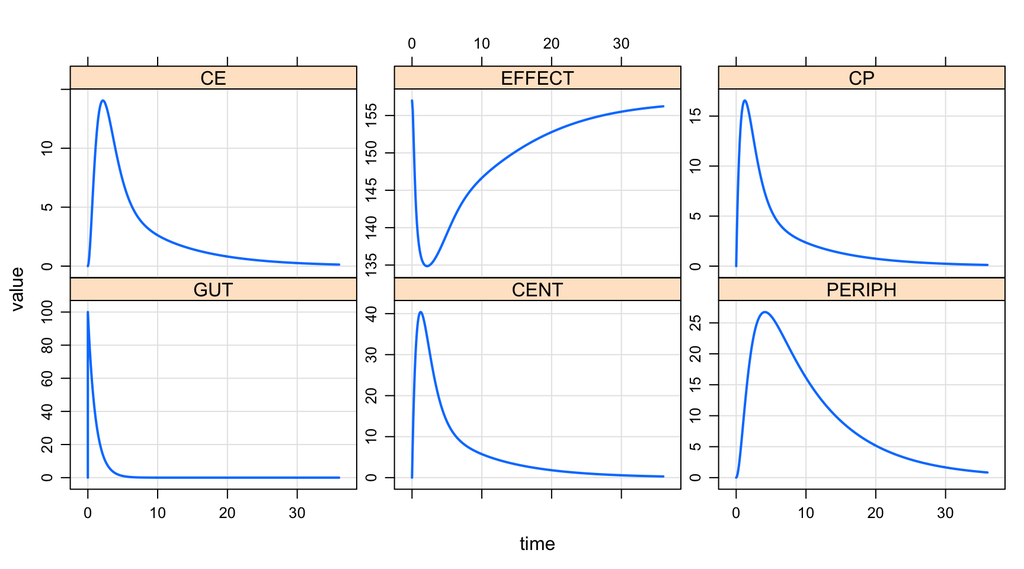

```r
mod %>% ev(amt = 100) %>% mrgsim() %>% plot
```

# Plot

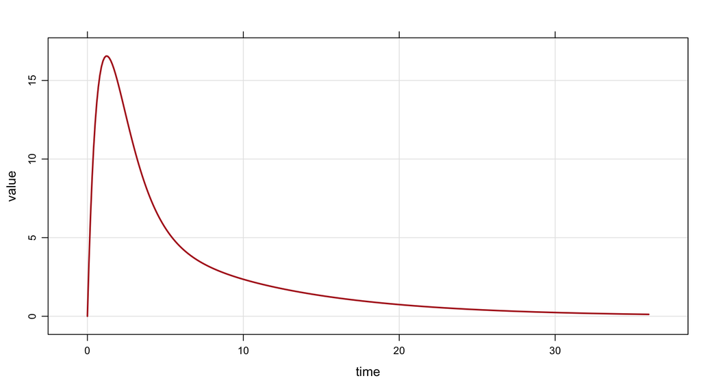

```r
mod %>% ev(amt = 100) %>% mrgsim() %>% plot(CP~., col = "firebrick")
```

# Pipeline

```r
mod %>% mrgsim() %>% mutate(arm = 1)
```

```
. # A tibble: 361 x 9
.       ID  time   GUT  CENT PERIPH    CE EFFECT    CP   arm
.    <dbl> <dbl> <dbl> <dbl>  <dbl> <dbl>  <dbl> <dbl> <dbl>
.  1  1.00 0         0     0      0     0    157     0  1.00
.  2  1.00 0.100     0     0      0     0    157     0  1.00
.  3  1.00 0.200     0     0      0     0    157     0  1.00
.  4  1.00 0.300     0     0      0     0    157     0  1.00
.  5  1.00 0.400     0     0      0     0    157     0  1.00
.  6  1.00 0.500     0     0      0     0    157     0  1.00
.  7  1.00 0.600     0     0      0     0    157     0  1.00
.  8  1.00 0.700     0     0      0     0    157     0  1.00
.  9  1.00 0.800     0     0      0     0    157     0  1.00
. 10  1.00 0.900     0     0      0     0    157     0  1.00
. # ... with 351 more rows
```

# What would you like to “fix” in this plot?

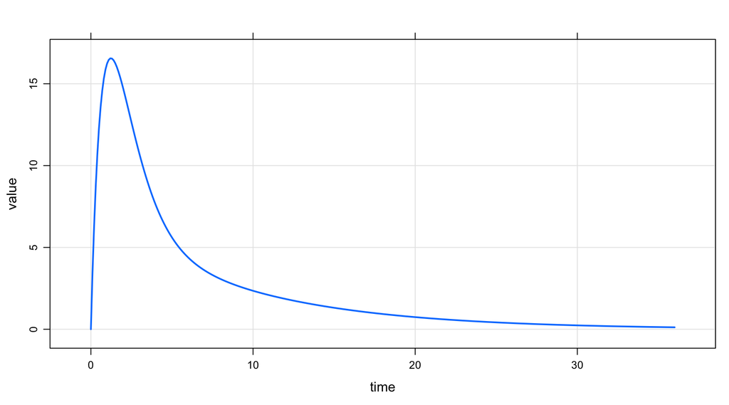

```r
mod %>% ev(amt = 100) %>% mrgsim() %>% plot(CP~time)
```

# Simulation end time

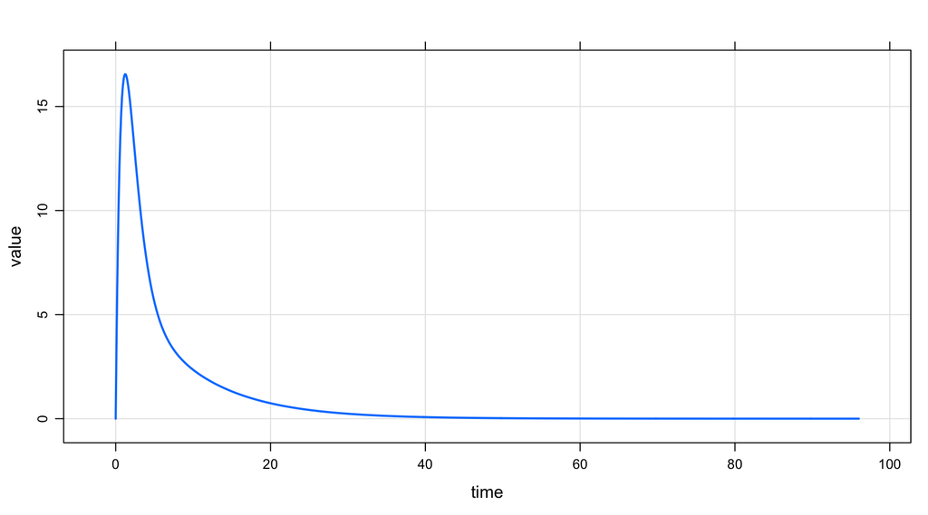

```r
mod %>% ev(amt = 100) %>% mrgsim(end = 96) %>% plot(CP~time)
```

# Simulation time step

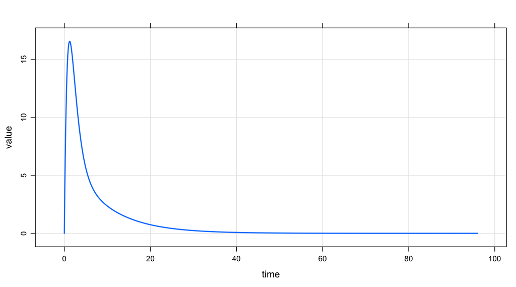

```r
mod %>% ev(amt = 100) %>% mrgsim(end = 96, delta = 0.1) %>% plot(CP~time)
```

# Simulation time grid

- To form a sequence of times
  - start usually `0`
  - end time of last observation
  - delta output time step
- Additional times to simulate
  - add ad-hoc numeric vector

```r
stime(mod)
```

```
.   [1]  0.0  0.1  0.2  0.3  0.4  0.5  0.6  0.7  0.8  0.9  1.0  1.1  1.2  1.3
.  [15]  1.4  1.5  1.6  1.7  1.8  1.9  2.0  2.1  2.2  2.3  2.4  2.5  2.6  2.7
.  [29]  2.8  2.9  3.0  3.1  3.2  3.3  3.4  3.5  3.6  3.7  3.8  3.9  4.0  4.1
.  [43]  4.2  4.3  4.4  4.5  4.6  4.7  4.8  4.9  5.0  5.1  5.2  5.3  5.4  5.5
.  [57]  5.6  5.7  5.8  5.9  6.0  6.1  6.2  6.3  6.4  6.5  6.6  6.7  6.8  6.9
.  [71]  7.0  7.1  7.2  7.3  7.4  7.5  7.6  7.7  7.8  7.9  8.0  8.1  8.2  8.3
.  [85]  8.4  8.5  8.6  8.7  8.8  8.9  9.0  9.1  9.2  9.3  9.4  9.5  9.6  9.7
.  [99]  9.8  9.9 10.0 10.1 10.2 10.3 10.4 10.5 10.6 10.7 10.8 10.9 11.0 11.1
. [113] 11.2 11.3 11.4 11.5 11.6 11.7 11.8 11.9 12.0 12.1 12.2 12.3 12.4 12.5
. [127] 12.6 12.7 12.8 12.9 13.0 13.1 13.2 13.3 13.4 13.5 13.6 13.7 13.8 13.9
. [141] 14.0 14.1 14.2 14.3 14.4 14.5 14.6 14.7 14.8 14.9 15.0 15.1 15.2 15.3
. [155] 15.4 15.5 15.6 15.7 15.8 15.9 16.0 16.1 16.2 16.3 16.4 16.5 16.6 16.7
. [169] 16.8 16.9 17.0 17.1 17.2 17.3 17.4 17.5 17.6 17.7 17.8 17.9 18.0 18.1
. [183] 18.2 18.3 18.4 18.5 18.6 18.7 18.8 18.9 19.0 19.1 19.2 19.3 19.4 19.5
. [197] 19.6 19.7 19.8 19.9 20.0 20.1 20.2 20.3 20.4 20.5 20.6 20.7 20.8 20.9
. [211] 21.0 21.1 21.2 21.3 21.4 21.5 21.6 21.7 21.8 21.9 22.0 22.1 22.2 22.3
. [225] 22.4 22.5 22.6 22.7 22.8 22.9 23.0 23.1 23.2 23.3 23.4 23.5 23.6 23.7
. [239] 23.8 23.9 24.0 24.1 24.2 24.3 24.4 24.5 24.6 24.7 24.8 24.9 25.0 25.1
. [253] 25.2 25.3 25.4 25.5 25.6 25.7 25.8 25.9 26.0 26.1 26.2 26.3 26.4 26.5
. [267] 26.6 26.7 26.8 26.9 27.0 27.1 27.2 27.3 27.4 27.5 27.6 27.7 27.8 27.9
. [281] 28.0 28.1 28.2 28.3 28.4 28.5 28.6 28.7 28.8 28.9 29.0 29.1 29.2 29.3
. [295] 29.4 29.5 29.6 29.7 29.8 29.9 30.0 30.1 30.2 30.3 30.4 30.5 30.6 30.7
. [309] 30.8 30.9 31.0 31.1 31.2 31.3 31.4 31.5 31.6 31.7 31.8 31.9 32.0 32.1
. [323] 32.2 32.3 32.4 32.5 32.6 32.7 32.8 32.9 33.0 33.1 33.2 33.3 33.4 33.5
. [337] 33.6 33.7 33.8 33.9 34.0 34.1 34.2 34.3 34.4 34.5 34.6 34.7 34.8 34.9
. [351] 35.0 35.1 35.2 35.3 35.4 35.5 35.6 35.7 35.8 35.9 36.0
```

# Update

```r
mod <- update(mod, end = 72)
```

```r
mod %>% update(end = 72) %>% mrgsim()
```

`mrgsim` will call `update` for you

```r
mod %>% mrgsim(end = 72)
```

# What else can I update?

- Solver settings
  - `atol`, `rtol`
  - `hmax`, `maxsteps`, `mxhnil`, `ixpr`
- `$OMEGA`, `$SIGMA`
- `tscale` (rescale the output time)
- `digits`

```r
mod %>% update(rtol = 1E-12) %>% ...
```

```r
mod %>% mrgsim(rtol = 1E-12) %>% ...
```